# HappyMoment

Yimeng Qiu

9/18/2018

# 1.introduction

What is the most important thing for your life? Money? Social Status? Achievement? Contribution? For me, happy is my long term pursuit. Though this project, we will analyize over 100,000 record about the idividuals’ happy moments. Utilizing text mining and NLP methods, we will find out the source of happyness. I seperate the dataset apart accourding to the High Income Economy countries list, so the focus of this project is to explore weather the level of economic development of country influnce the happyness of its citizen? Is any difference of happy source between two groups? Will the sentiment analysis and topic model analysis despribe the difference of two group. Let’s start our research!

# 2. Preparation

Check and install needed packages. Load the libraries and functions.

```r
packages.used=c("rvest", "tibble", "qdap",
                "sentimentr", "gplots", "dplyr",
                "tm", "syuzhet", "factoextra",
                "beeswarm", "scales", "RColorBrewer",
                "RANN", "tm", "topicmodels")

# check packages that need to be installed.
packages.needed=setdiff(packages.used,
                        intersect(installed.packages()[,1],
                                  packages.used))
# install additional packages
if(length(packages.needed)>0){
  install.packages(packages.needed, dependencies = TRUE)
}

# load packages
library("rvest")
library("tibble")
library("sentimentr")
library("gplots")
library("dplyr")
library("tm")
library("syuzhet")
library("factoextra")
library("beeswarm")
library("scales")
library("RColorBrewer")
library("RANN")
library("tm")
library("topicmodels")
library("tidyverse")
library("tidytext")
library("DT")
library("wordcloud2")
library("gridExtra")
library("ngram")
library("wordcloud")
```

# 3. Data Harvest

## Step 1: load the cleaned_hm.csv and demographic.csv from https://rit-public.github.io/HappyDB/

```r
hm_data <- read_csv("../output/processed_moments.csv")

urlfile<-'https://raw.githubusercontent.com/rit-public/HappyDB/master/happydb/data/demographic.csv'
demo_data <- read_csv(urlfile)
```

## Step 2: Scrapping the country list from https://en.wikipedia.org/wiki/Developed_country by using python.

The definition of High Income Economy is from https://en.wikipedia.org/wiki/World_Bank_high-income_economy

```r
hie <- read.table('/Users/Janice/Documents/GitHub/2018adsfallproject1/data/HIE.csv',header = F,as.is = T)[[1]]
```

## Step 3: Basic data wrangling, and seperate the dataset apart accourding to the definition of HIE.

```r
hm_data <- hm_data %>%
  inner_join(demo_data, by = "wid") %>%
  select(wid,
         original_hm,
         gender,
         marital,
         parenthood,
         reflection_period,
         age,
         country,
         ground_truth_category,
         text) %>%
  mutate(count = sapply(hm_data$text, wordcount)) %>%
  filter(gender %in% c("m", "f")) %>%
  filter(marital %in% c("single", "married")) %>%
  filter(parenthood %in% c("n", "y")) %>%
  filter(reflection_period %in% c("24h", "3m")) %>%
  mutate(reflection_period = fct_recode(reflection_period,
                                        months_3 = "3m", hours_24 = "24h"))


countrylist <- names(table(hm_data$country))
nhie <- countrylist[!(countrylist %in% hie)]

hie_data <- hm_data %>%
  filter(country %in% hie)

nhie_data <- hm_data %>%
  filter(!country %in% hie)
```

# 4. What is the difference of happy source between two groups?

Assume that the order of words does not matter, here, we first conduct a preliminary research on what the most frequently mentioned words are in the happy moment dataset. In order to make the analysis more practical, stop words such as “I”, “am” and punctuation are removed.

```r
bag_of_words <-  hm_data %>%
  unnest_tokens(word, text)

word_count <- bag_of_words %>%
  count(word, sort = TRUE)

bag_of_hie <-  hie_data %>%
  unnest_tokens(word, text)

word_hie <- bag_of_hie %>%
  count(word, sort = TRUE)

bag_of_nhie <-  nhie_data %>%
  unnest_tokens(word, text)

word_nhie <- bag_of_nhie %>%
  count(word, sort = TRUE)
```

[figure not shown]

```r
par(mfrow=c(3,1))
word_count.1 = word_count[4:nrow(word_count),]
wordcloud(word_count.1$word, word_count.1$n,  # the wordcloud of total dataset
          scale=c(5,0.005),
          max.words=100,
          min.freq=1,
          random.order=FALSE,
          rot.per=F,
          use.r.layout=T,
          random.color=FALSE,
          colors=brewer.pal(9,"Greens"))

word_hie.1 = word_hie[4:nrow(word_hie),]
wordcloud(word_hie.1$word,word_hie.1$n,  # the wordcloud of HIE group
          scale=c(5,0.5),
          max.words=100,
          min.freq=1,
          random.order=FALSE,
          rot.per=F,
          use.r.layout=T,
          random.color=FALSE,
          colors=brewer.pal(9,"Blues"))

word_nhie.1 = word_hie[4:nrow(word_nhie),]
wordcloud(word_nhie.1$word,word_nhie.1$n,  # the wordcloud of not the HIE group
          scale=c(5,0.5),
          max.words=100,
          min.freq=1,
          random.order=FALSE,
          rot.per=F,
          use.r.layout=T,
          random.color=FALSE,
          colors=brewer.pal(9,"Reds"))
```

List the frequency of words from the fourth one for both groups. The words frequency of HIE countries is decreasing linearly, however, the none HIE countries has huge gap between the first word ‘moment’ and the second word ‘life’. From my understanding, I guess maybe this is becuase most of none HIE countries do not speak English, which will cuase some gramma problem to record the happy moments sentence. The happy moments words from HIE countries are clear, more about family, work; on the other side, none HIE countries, the happy moments words are hard to interpretate, not as logical as the first group. Compared with HIE group, it is more about personal experience.

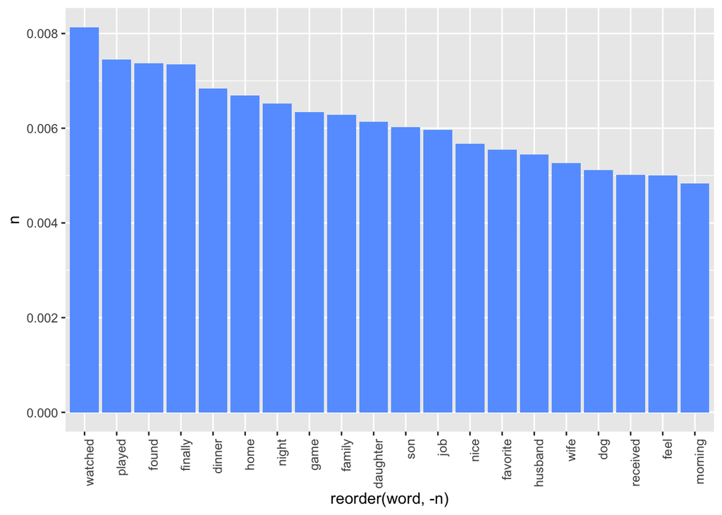

```r
word_hie$n <- word_hie$n/sum(word_hie$n)
word_nhie$n <- word_nhie$n/sum(word_nhie$n)
#barplot
par(mfrow=c(2,1))
ggplot(word_hie[4:23,],aes(x = reorder(word, -n), y = n))+geom_bar(stat="identity",fill='#66a0ff')+theme(axis.text.x = element_text(angle = 90, hjust = 1))
```

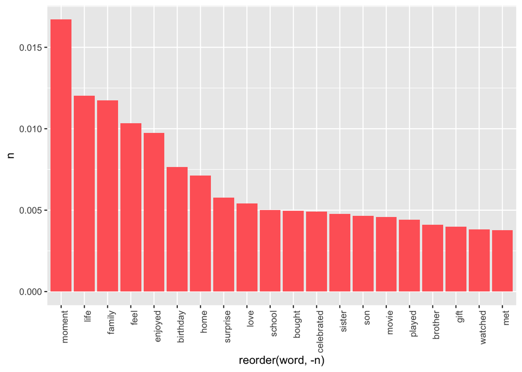

```r
ggplot(word_nhie[4:23,],aes(x = reorder(word, -n), y = n))+geom_bar(stat="identity", fill = "#FF6666")+theme(axis.text.x = element_text(angle = 90, hjust = 1))
```

# 5. Can emotion analysis help us to explane the difference behind two groups?

## Step 1: convert the data to emotion index matrix from NRC.

from the cumulative barchart, ignoring the last four nagetive emotion, we can the HIE countries emphasize the anticipation more than those none HIE countries; the none HIE countries people need to more trust.

```r
senti_data <- bag_of_words %>%
  select(wid,word) %>%
  inner_join(get_sentiments("nrc")) %>%
  filter(!sentiment %in% c('positive','negative')) %>%
  left_join(bag_of_words)
senti_table <- as.data.frame(table(senti_data$sentiment))
senti_table$Freq <- senti_table$Freq/sum(senti_table$Freq)

senti_hic <- bag_of_hie %>%
  select(wid,word) %>%
  inner_join(get_sentiments("nrc")) %>%
  filter(!sentiment %in% c('positive','negative')) %>%
  left_join(bag_of_hie)
senti_hic_table <- as.data.frame(table(senti_hic$sentiment))
senti_hic_table$Freq <- senti_hic_table$Freq/sum(senti_hic_table$Freq)
senti_hic_table$type <- rep('HIE',8)

senti_nhic <- bag_of_nhie %>%
  select(wid,word) %>%
  inner_join(get_sentiments("nrc")) %>%
  filter(!sentiment %in% c('positive','negative')) %>%
  left_join(bag_of_nhie)
```

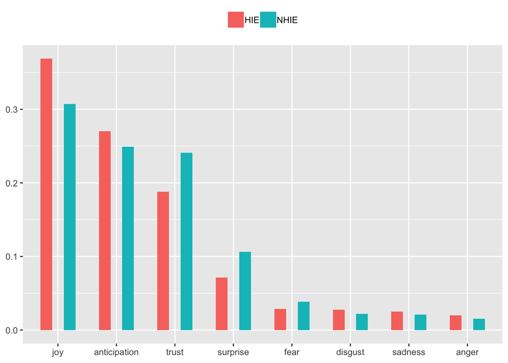

```r
senti_nhic_table <- as.data.frame(table(senti_nhic$sentiment))
senti_nhic_table$Freq <- senti_nhic_table$Freq/sum(senti_nhic_table$Freq)
senti_nhic_table$type <- rep('NHIE',8)

senti_total_table <- rbind(senti_nhic_table,senti_hic_table)

ggplot(senti_total_table,aes(x=reorder(Var1,-Freq),y=Freq))+geom_bar(stat="identity",aes(fill = type),width = 0.4,    position = position_dodge(width=0.8)) +
   theme(legend.position="top", legend.title =
   element_blank(),axis.title.x=element_blank(),
   axis.title.y=element_blank())
```

## Step 2: using the diffence of sentiment analysis, can we predict the type of country? (HIE or not)

First of all, I calculate avarage sentiment decimal value for each country, and use the sentiment decimal matrix to cluster whole data as two group. From the result for kmeans clustering, I find the sentiment analysis for none HIE countries has relatively higher accuracy rate. I can conclude countries in the none HIE group have some trend in sentiment weight. The accuracy rate for the none HIE gourp is near 0.6.

```r
f <- function(country_df){
  return(c(table(country_df$sentiment)[]
           ))
}

senti.split <- split(senti_data, senti_data$country)
senti.m <- sapply(senti.split, f)

senti <- names(senti.m[[2]])

senti.cm <- matrix(nrow=length(senti.m),ncol=8,0)
for (i in 1:length(senti.m)){
  k = 1
  for (j in senti){
    senti.cm[i,k]=ifelse(!is.null(senti.m[[i]][j]),senti.m[[i]][j],0)
    k <- k+1
  }
}
colnames(senti.cm) <- senti
rownames(senti.cm) <- names(senti.m)
senti.cm[is.na(senti.cm)] <- 0
senti.sum <- rowSums(senti.cm)
senti.cm <- senti.cm/senti.sum
```

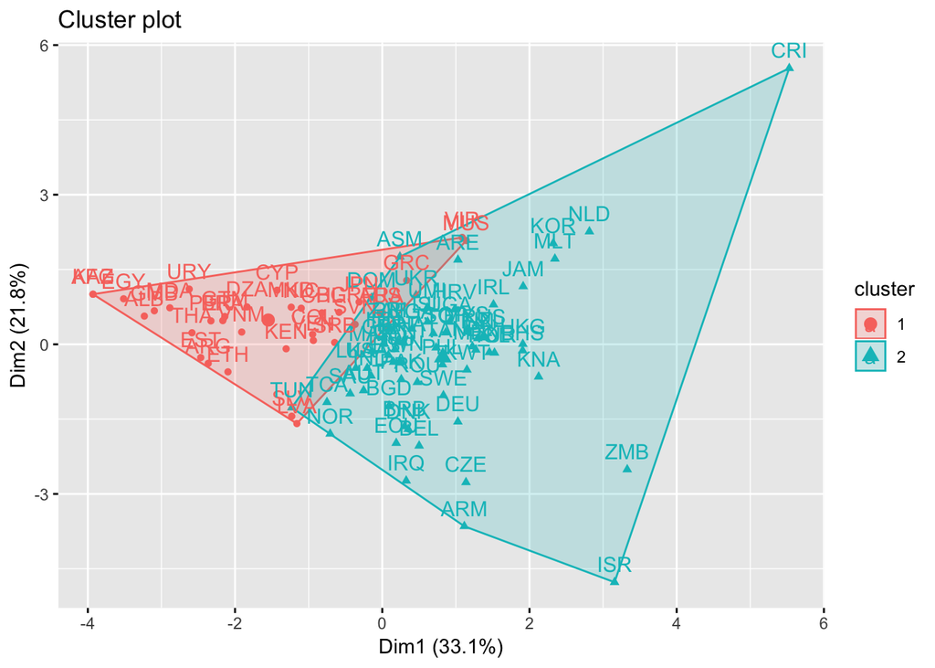

```r
km.res <- kmeans(senti.cm,2)
fviz_cluster(km.res, data = senti.cm)
```

```r
nhie_hat <- names(km.res$cluster)[km.res$cluster==2]
hie_hat <- names(km.res$cluster)[km.res$cluster==1]

common_hie <- intersect(hie,hie_hat)
common_nhie <- intersect(nhie,nhie_hat)

length(common_hie)/length(hie)
```

```
## [1] 0.1964286
```

```r
length(common_nhie)/length(nhie)
```

```
## [1] 0.5862069
```

# 6. Can topic analysis help us to explane the difference behind two groups?

## Step 1: data wrangling

```r
hm_data <- hm_data[sample(1:94574,15000,replace = F),] #my computer reach the calculation limits if I use whole dataset

hie_data <- hm_data %>%
  filter(country %in% hie)

nhie_data <- hm_data %>%
  filter(!country %in% hie)


docs <- Corpus(VectorSource(hm_data$text))
writeLines(as.character(docs[[sample(1:nrow(hm_data), 1)]]))
```

```
## stomach upset morning feel
```

```r
docs.hie <- Corpus(VectorSource(hie_data$text))
writeLines(as.character(docs[[sample(1:nrow(hie_data), 1)]]))
```

```
## bought guitar friend helped
```

```r
docs.nhie <- Corpus(VectorSource(nhie_data$text))
writeLines(as.character(docs[[sample(1:nrow(nhie_data), 1)]]))
```

```
## book flight hawaii super excited gleeful
```

data wrangling for whole dataset

```r
#remove potentially problematic symbols
docs <-tm_map(docs,content_transformer(tolower))
```

```r
writeLines(as.character(docs[[sample(1:nrow(hm_data), 1)]]))
```

```
## daughter dish supper
```

```r
#remove punctuation
docs <- tm_map(docs, removePunctuation)
```

```r
writeLines(as.character(docs[[sample(1:nrow(hm_data), 1)]]))
```

```
## weather started warmer
```

```r
#Strip digits
docs <- tm_map(docs, removeNumbers)
```

```r
writeLines(as.character(docs[[sample(1:nrow(hm_data), 1)]]))
```

```
## car delivered
```

```r
#remove stopwords
docs <- tm_map(docs, removeWords, stopwords("english"))
```

```r
writeLines(as.character(docs[[sample(1:nrow(hm_data), 1)]]))
```

```
## adopted pup shelter joy
```

```r
#remove whitespace
docs <- tm_map(docs, stripWhitespace)
```

```r
writeLines(as.character(docs[[sample(1:nrow(hm_data), 1)]]))
```

```
## son wrote board exam results announced score moment
```

```r
#Stem document
docs <- tm_map(docs,stemDocument)
```

```r
writeLines(as.character(docs[[sample(1:nrow(hm_data), 1)]]))
```

```
## found niec bring cat visit fun love cat
```

data wrangling for HIE dataset

```r
#remove potentially problematic symbols
docs.hie <-tm_map(docs.hie,content_transformer(tolower))
writeLines(as.character(docs.hie[[sample(1:nrow(hie_data), 1)]]))
```

```
## walk snow
```

```r
#remove punctuation
docs.hie <- tm_map(docs.hie, removePunctuation)
writeLines(as.character(docs.hie[[sample(1:nrow(hie_data), 1)]]))
```

```
## found quarter ground apartment
```

```r
#Strip digits
docs.hie <- tm_map(docs.hie, removeNumbers)
writeLines(as.character(docs.hie[[sample(1:nrow(hie_data), 1)]]))
```

```
## doctor lab results normal
```

```r
#remove stopwords
docs.hie <- tm_map(docs.hie, removeWords, stopwords("english"))
writeLines(as.character(docs.hie[[sample(1:nrow(hie_data), 1)]]))
```

```
## taking time finished dish
```

```r
#remove whitespace
docs.hie <- tm_map(docs.hie, stripWhitespace)
writeLines(as.character(docs.hie[[sample(1:nrow(hie_data), 1)]]))
```

```
## free tickets nice concert
```

```r
#Stem document
docs.hie <- tm_map(docs.hie,stemDocument)
writeLines(as.character(docs.hie[[sample(1:nrow(hie_data), 1)]]))
```

```
## extrem receiv item babi nurseri
```

data wrangling for none HIE dataset

```r
#remove potentially problematic symbols
docs.nhie <-tm_map(docs.nhie,content_transformer(tolower))
```

```r
writeLines(as.character(docs.nhie[[sample(1:nrow(nhie_data), 1)]]))
```

```
## day friend called enjoyed
```

```r
#remove punctuation
docs.nhie <- tm_map(docs.nhie, removePunctuation)
```

```r
writeLines(as.character(docs.nhie[[sample(1:nrow(nhie_data), 1)]]))
```

```
## time native spent time grandmother ride friend
```

```r
#Strip digits
docs.nhie <- tm_map(docs.nhie, removeNumbers)
```

```r
writeLines(as.character(docs.nhie[[sample(1:nrow(nhie_data), 1)]]))
```

```
## blissful moment mine home pet missed terrible day
```

```r
#remove stopwords
docs.nhie <- tm_map(docs.nhie, removeWords, stopwords("english"))
```

```r
writeLines(as.character(docs.nhie[[sample(1:nrow(nhie_data), 1)]]))
```

```
## daughter god marks annual examinationshe makes proud
```

```r
#remove whitespace
docs.nhie <- tm_map(docs.nhie, stripWhitespace)
```

```r
writeLines(as.character(docs.nhie[[sample(1:nrow(nhie_data), 1)]]))
```

```
## dad job opportunity foreign country
```

```r
#Stem document
docs.nhie <- tm_map(docs.nhie,stemDocument)
```

```r
writeLines(as.character(docs.nhie[[sample(1:nrow(nhie_data), 1)]]))
```

```
## moment life appear won world fare examin anxious result pleas friend rank mark celebr pleasur friend chalk programm decid picnic decid surajkund reach hour picnic spot crowd lot peopl occupi enjoy
```

```r
# get the dtm for whole data
dtm <- DocumentTermMatrix(docs)
#convert rownames to filenames#convert rownames to filenames
rownames(dtm) <- hm_data$wid
rowTotals <- apply(dtm , 1, sum) #Find the sum of words in each Document
dtm  <- dtm[rowTotals> 0, ]


# get the dtm for HIE group data
dtm.hie <- DocumentTermMatrix(docs.hie)
#convert rownames to filenames#convert rownames to filenames
rownames(dtm.hie) <- hie_data$wid
rowTotals <- apply(dtm.hie , 1, sum) #Find the sum of words in each Document
dtm.hie  <- dtm.hie[rowTotals> 0, ]

# get the dtm for none HIE group data
dtm.nhie <- DocumentTermMatrix(docs.nhie)
#convert rownames to filenames#convert rownames to filenames
rownames(dtm.nhie) <- nhie_data$wid
rowTotals <- apply(dtm.nhie , 1, sum) #Find the sum of words in each Document
dtm.nhie  <- dtm.nhie[rowTotals> 0, ]
```

## step 2: training data using topic model

```r
#Set parameters for Gibbs sampling
burnin <- 4000
iter <- 2000
thin <- 500
seed <-list(2003,5,63,100001,765)
nstart <- 5
best <- TRUE

#Number of topics
k <- 6

#Run LDA using Gibbs sampling
ldaOut <-LDA(dtm, k, method="Gibbs", control=list(nstart=nstart,
                                                 seed = seed, best=best,
                                                 burnin = burnin, iter = iter,
                                                 thin=thin))

#docs to topics
ldaOut.topics <- as.matrix(topics(ldaOut))
table(c(1:k, ldaOut.topics))
```

```
##
##    1    2    3    4    5    6
## 3669 3210 2932 2004 1904 1283
```

```r
#top 6 terms in each topic
ldaOut.terms <- as.matrix(terms(ldaOut,20))

#probabilities associated with each topic assignment
topicProbabilities <- as.data.frame(ldaOut@gamma)
```

```r
terms.beta=ldaOut@beta
terms.beta=scale(terms.beta)
topics.terms=NULL
for(i in 1:k){
  topics.terms=rbind(topics.terms, ldaOut@terms[order(terms.beta[i,], decreasing = TRUE)[1:7]])
}
topics.terms
```

```
##      [,1]     [,2]     [,3]     [,4]         [,5]      [,6]       [,7]
## [1,] "talk"   "finish" "gift"   "celebr"     "phone"   "babi"     "meet"
## [2,] "job"    "receiv" "ive"    "buy"        "store"   "onlin"    "manag"
## [3,] "watch"  "night"  "game"   "girlfriend" "movi"    "food"     "fun"
## [4,] "famili" "visit"  "father" "cousin"     "left"    "movement" "templ"
## [5,] "dog"    "walk"   "cat"    "clean"      "park"    "woke"     "rain"
## [6,] "feel"   "happi"  "make"   "pass"       "student" "music"    "experi"
```

```r
#Set parameters for Gibbs sampling
burnin <- 4000
iter <- 2000
thin <- 500
seed <-list(2003,5,63,100001,765)
nstart <- 5
best <- TRUE

#Number of topics
k <- 6

#Run LDA using Gibbs sampling
ldaOut_hie <-LDA(dtm.hie, k, method="Gibbs", control=list(nstart=nstart,
                                                 seed = seed, best=best,
                                                 burnin = burnin, iter = iter,
                                                 thin=thin))
#write out results
#docs to topics
ldaOut_hie.topics <- as.matrix(topics(ldaOut_hie))
table(c(1:k, ldaOut_hie.topics))
```

```
##
##    1    2    3    4    5    6
## 2775 2317 1493 2153 1669 1479
```

```r
#top 6 terms in each topic
ldaOut_hie.terms <- as.matrix(terms(ldaOut_hie,20))

#probabilities associated with each topic assignment
topicProbabilities_hie <- as.data.frame(ldaOut_hie@gamma)
```

```r
terms_hie.beta=ldaOut_hie@beta
terms_hie.beta=scale(terms_hie.beta)
topics_hie.terms=NULL
for(i in 1:k){
  topics_hie.terms=rbind(topics_hie.terms, ldaOut_hie@terms[order(terms_hie.beta[i,], decreasing = TRUE)[1:7]])
}
topics_hie.terms
```

```
##      [,1]       [,2]    [,3]    [,4]     [,5]     [,6]      [,7]
## [1,] "money"    "clean" "buy"   "shop"   "ticket" "pick"    "save"
## [2,] "complet"  "phone" "card"  "promot" "read"   "bonus"   "check"
## [3,] "school"   "life"  "learn" "class"  "person" "graduat" "meet"
## [4,] "play"     "wife"  "won"   "ate"    "cook"   "local"   "cake"
## [5,] "birthday" "drink" "mine"  "cousin" "heard"  "special" "rare"
## [6,] "day"      "son"   "dog"   "run"    "park"   "beauti"  "bed"
```

```r
#Set parameters for Gibbs sampling
burnin <- 4000
iter <- 2000
thin <- 500
seed <-list(2003,5,63,100001,765)
nstart <- 5
best <- TRUE

#Number of topics
k <- 6

#Run LDA using Gibbs sampling
ldaOut_nhie <-LDA(dtm.nhie, k, method="Gibbs", control=list(nstart=nstart,
                                                 seed = seed, best=best,
                                                 burnin = burnin, iter = iter,
                                                 thin=thin))
#write out results
#docs to topics
ldaOut_nhie.topics <- as.matrix(topics(ldaOut_nhie))
table(c(1:k, ldaOut_nhie.topics))
```

```
##
##   1   2   3   4   5   6
## 847 654 564 414 361 282
```

```r
#top 6 terms in each topic
ldaOut_nhie.terms <- as.matrix(terms(ldaOut_nhie,20))

#probabilities associated with each topic assignment
topicProbabilities_nhie <- as.data.frame(ldaOut_nhie@gamma)
```

```r
terms_nhie.beta=ldaOut_nhie@beta
terms_nhie.beta=scale(terms_nhie.beta)
topics_nhie.terms=NULL
for(i in 1:k){
  topics_nhie.terms=rbind(topics_nhie.terms, ldaOut_nhie@terms[order(terms_nhie.beta[i,], decreasing = TRUE)[1:7]])
}
topics_nhie.terms
```

```
##      [,1]     [,2]      [,3]      [,4]     [,5]     [,6]     [,7]
## [1,] "job"    "favorit" "nice"    "won"    "team"   "care"   "rain"
## [2,] "home"   "sister"  "gift"    "phone"  "babi"   "dad"    "sudden"
## [3,] "friend" "school"  "fun"     "pass"   "park"   "expect" "examin"
## [4,] "famili" "person"  "husband" "wait"   "travel" "mobil"  "unforgett"
## [5,] "love"   "girl"    "uncl"    "trip"   "happen" "run"    "propos"
## [6,] "start"  "visit"   "rememb"  "memori" "news"   "beach"  "vacat"
```

## Step 3: get the heatmap for two group

```r
# whole data process
topics.hash=c("Work", "Family", "Achievement", "Friend","Play", "Relax")
l = length(ldaOut.topics)
hm_data = hm_data[1:l,]
hm_data$ldatopic=as.vector(ldaOut.topics)
hm_data$ldahash=topics.hash[ldaOut.topics]
colnames(topicProbabilities)=topics.hash
corpus.list.df=cbind(hm_data, topicProbabilities)
```

```r
# HIE data process
topics.hash.hie=c("Comsuption", "Family", "Friend","Eat", "Achievement", "Work")
l = length(ldaOut_hie.topics)
hie_data = hie_data[1:l,]
hie_data$ldatopic=as.vector(ldaOut_hie.topics)
hie_data$ldahash=topics.hash.hie[ldaOut_hie.topics]
colnames(topicProbabilities_hie)=topics.hash.hie
corpus_hie.list.df=cbind(hie_data, topicProbabilities_hie)
```

```r
# none HIE data process
topics.hash.nhie=c("Excercise", "Family", "Social","Eat", "Achievement", "Travel")
l = length(ldaOut_nhie.topics)
nhie_data = nhie_data[1:l,]
nhie_data$ldatopic=as.vector(ldaOut_nhie.topics)
nhie_data$ldahash=topics.hash.nhie[ldaOut_nhie.topics]
colnames(topicProbabilities_nhie)=topics.hash.nhie
corpus_nhie.list.df=cbind(nhie_data, topicProbabilities_nhie)
```

```r
# get the topic summary for whole dataset
topic.summary=tbl_df(corpus.list.df)%>%
  select(country, Work:Relax)%>%
  group_by(country)%>%
  summarise_each(funs(mean))
```

```
## `summarise_each()` is deprecated.
## Use `summarise_all()`, `summarise_at()` or `summarise_if()` instead.
## To map `funs` over all variables, use `summarise_all()`
```

```r
# get the topic summary for HIE group
topic_hie.summary=tbl_df(corpus_hie.list.df)%>%
  select(country, Comsuption:Work)%>%
  group_by(country)%>%
  summarise_each(funs(mean))
```

```
## `summarise_each()` is deprecated.
## Use `summarise_all()`, `summarise_at()` or `summarise_if()` instead.
## To map `funs` over all variables, use `summarise_all()`
```

```r
# get the topic summary for noen HIE group
corpus_nhie.list.df=cbind(nhie_data, topicProbabilities_nhie)
topic_nhie.summary=tbl_df(corpus_nhie.list.df)%>%
  select(country, Excercise:Travel)%>%
  group_by(country)%>%
  summarise_each(funs(mean))
```

```
## `summarise_each()` is deprecated.
## Use `summarise_all()`, `summarise_at()` or `summarise_if()` instead.
## To map `funs` over all variables, use `summarise_all()`
```

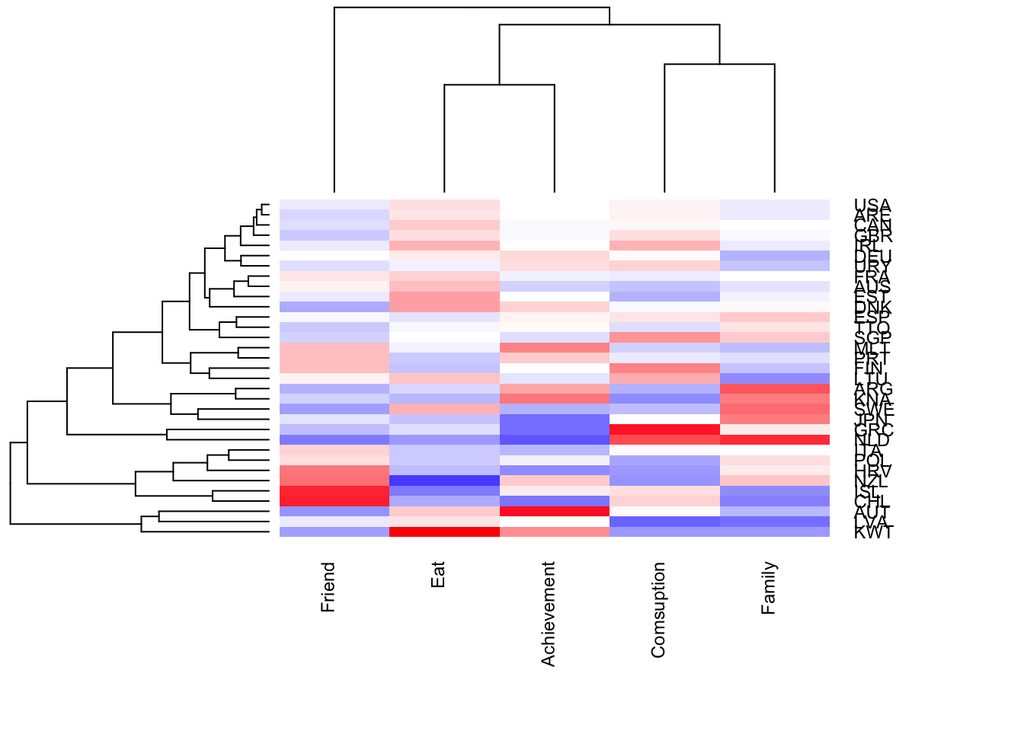

```r
topic_hie.summary=as.data.frame(topic_hie.summary)
rownames(topic_hie.summary)=topic_hie.summary[,1]

heatmap.2(as.matrix(topic_hie.summary[,2:6]),
          scale = "column", key=F,
          col = bluered(100),
          cexRow = 0.9, cexCol = 0.9, margins = c(8, 8),
          trace = "none", density.info = "none")
```

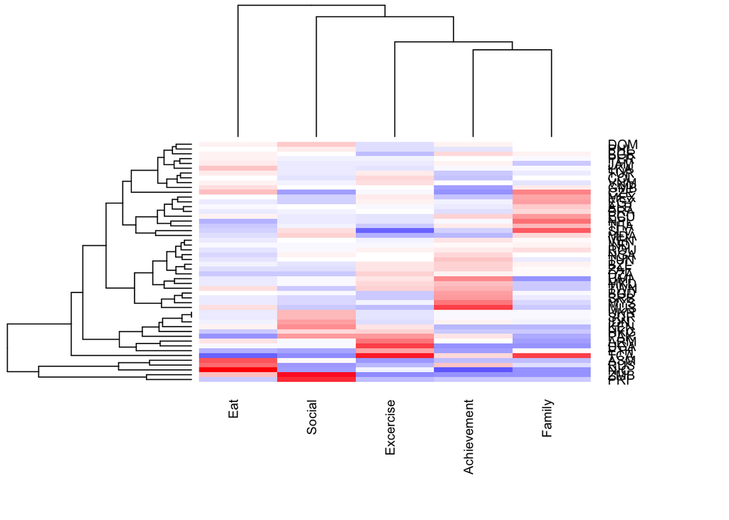

```r
topic_nhie.summary=as.data.frame(topic_nhie.summary)
topic_nhie.summary[,1] = c(topic_nhie.summary[,1][-length(topic_nhie.summary[,1])],"BZL")
rownames(topic_nhie.summary)= topic_nhie.summary[,1]

heatmap.2(as.matrix(topic_nhie.summary[,2:6]),
          scale = "column", key=F,
          col = bluered(100),
          cexRow = 0.9, cexCol = 0.9, margins = c(8, 8),
          trace = "none", density.info = "none")
```

## Step 4: using kmeans to cluster whole dataset as two group

From the clustring result, most coutries are assinged as the same group, which is the reason the accuracy of HIE group cluster not reach 0.5. Considering the research, I think, not matter what the development level of country, people’s happly moment source are the same.

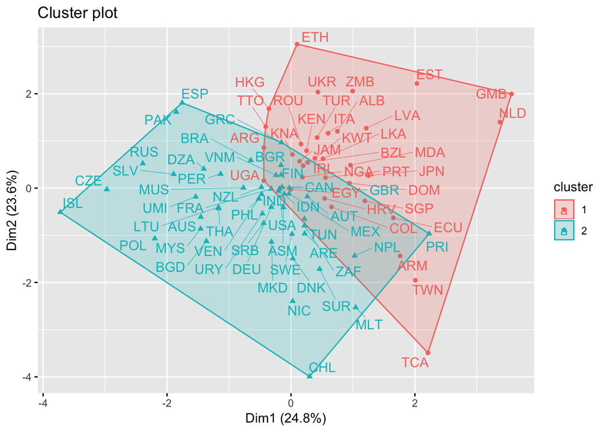

```r
topic.summary=as.data.frame(topic.summary)
namess = c(as.character((topic.summary[,1]))[-length(as.character((topic.summary[,1])))],'BZL')
rownames(topic.summary)=namess
km.res=kmeans(scale(topic.summary[,-1]), iter.max=200,
              2)
fviz_cluster(km.res,
             stand=T, repel= TRUE,
             data = topic.summary[,-1],
             show.clust.cent=FALSE)
```

```r
nhie_hat <- names(km.res$cluster)[km.res$cluster==2]
hie_hat <- names(km.res$cluster)[km.res$cluster==1]

common_hie <- intersect(hie,hie_hat)
common_nhie <- intersect(nhie,nhie_hat)

length(common_hie)/length(hie)
```

```
## [1] 0.2321429
```

```r
length(common_nhie)/length(nhie)
```

```
## [1] 0.4827586
```

# Conclusion

From this topic, I use EDA, sentiment analysis and topic model analysis dig the difference betweent people from Hign Income Economy or not deeper, and find there is indeed some difference between two group. However, the last topic model tells me, generally speaking, the happy sources for all people no matter which country are you from are the same: Family, Friend, Achievement, Travel. From this really interesting project, I know for my long term persuit, I need spend more time with my family and friend, and also work hard to achieve the success of study and work.